# Human and Economic Costs by Storm Type

Dave Sutter

2022-11-16

# Synopsis

We examine the storm data file provided by the United States National Weather Service to find the storm types that do the most total yearly damage in terms of fatalities, injuries and dollar cost damage.

The storm data file used includes storm events from 1950 until 2011. We limited the events to those between 1996, where the data quality increased, and the last complete year of data, since the storm types vary by time of year.

The main task in analyzing the file is interpreting the storm type labels. We did keyword matching using a curated list of keywords to help map the event type labels to the official storm type names used by the National Weather Service.

We then summed the total fatalities, injuries and damage costs for each type and averaged to estimate the yearly amounts.

The storm type with the highest average yearly fatalities is *Excessive Heat*, injuries is *Tornado*, and dollar damage is *Flood*.

# Data Processing

We are processing storm data from the United States National Weather Service.

### Source Data Used in Analysis

National Weather Service Storm Data, 1950 to Nov, 2011:

https://d396qusza40orc.cloudfront.net/repdata%2Fdata%2FStormData.csv.bz2

National Weather Service Storm Data Documentation:

https://d396qusza40orc.cloudfront.net/repdata%2Fpeer2_doc%2Fpd01016005curr.pdf

National Climatic Data Center Storm Events FAQ:

https://d396qusza40orc.cloudfront.net/repdata%2Fpeer2_doc%2FNCDC%20Storm%20Events-FAQ%20Page.pdf

There is updated storm data available from the National Weather Service website:

https://www.ncdc.noaa.gov/stormevents/details.jsp

### Utility Functions

The following are some simple functions that are used in the analysis. It is recommended that you skip this section and come back to it later for more information if desired

```r
##=====================================
## This function converts exponent strings to numerical exponents
##=====================================
## This converts exponent string values that are
## - a number of metric exponents - see code for selection
## - numeric strings (convert to numeric)
## - other - anything else is converted to an exponent of 0
## In addition a safety text is done that there are no single letter
## values that are not converted by the metric coefficients, with the
## assumption that theis coefficient should be added.
convertExpCol <- function(expStr) {
  expNum <- numeric(length(expStr))
  expNum <- NA

  expNum[str_detect(expStr,"[hH]")] = 2
  expNum[str_detect(expStr,"[kK]")] = 3
  expNum[str_detect(expStr,"[mM]")] = 6
  expNum[str_detect(expStr,"[bB]")] = 9
  expNum[str_detect(expStr,"[tT]")] = 12

  isnum <- str_detect(expStr,"[0-9]+")
  expNum[isnum] = as.numeric(expStr[isnum])

  ## SAFETY TEST --------
  ## Check for any remaining single letter exponents
  ## These are probably metric prefixes we left out
  singleLetterExpLeft <- sum(str_detect(expStr[is.na(expNum)],"[a-zA-Z]"))
  if(singleLetterExpLeft > 0) {
    error("There are unaccounted letter values for exponent! Investigate")
  }
  ##--------------

  expNum[is.na(expNum)] = 0

  expNum
}

## standardize string - lowercase and replace dash with space
stdString <- function(textVector) {
  str_replace(tolower(textVector),"-"," ")
}


## this function takes a vector of outerStrings and innerStrings and returns a matrix
## telling if a given outerString contains a given innerString. The outerStrings represent
## row indices and the innerStrings represent column indices
getContainedIn <- function(outerStrings,innerStrings) {
  inner_in_outer <- matrix(FALSE,nrow = length(outerStrings),ncol = length(innerStrings))
  dimnames(inner_in_outer) <- list(outerStrings,innerStrings)

  setRow <- function(outerString) {
    inner_in_outer[outerString,] <<- str_detect(outerString,regex(innerStrings,ignore_case=TRUE))
  }

  sapply(outerStrings,setRow)

  inner_in_outer
}
```

### Loading Data

Here we read in the data from the NWS storm data file.

The storm file has been downloaded from the URL listed above and is present as the location specified in the code below.

We added some additional code to specify the column classes and to exclude some unneeded columns, to limit the resources needed at load time.

There is also a safety check to verify the format of the file is as expected. An error will be given if the format of the file does not match the expected format. If this is true, a number of names in the code will have to be updated to run this document.

```r
## This is a list of column names for the data
colNames <- c("STATE__", "BGN_DATE", "BGN_TIME", "TIME_ZONE", "COUNTY",
              "COUNTYNAME", "STATE", "EVTYPE", "BGN_RANGE", "BGN_AZI",
              "BGN_LOCATI", "END_DATE", "END_TIME", "COUNTY_END", "COUNTYENDN",
              "END_RANGE", "END_AZI", "END_LOCATI", "LENGTH", "WIDTH", "F",
              "MAG", "FATALITIES", "INJURIES", "PROPDMG", "PROPDMGEXP",
              "CROPDMG", "CROPDMGEXP", "WFO", "STATEOFFIC", "ZONENAMES",
              "LATITUDE", "LONGITUDE", "LATITUDE_E", "LONGITUDE_", "REMARKS",
              "REFNUM")

## place the column names you want to keep here
colToKeep <- c("BGN_DATE","EVTYPE","FATALITIES","INJURIES","PROPDMG",
               "PROPDMGEXP","CROPDMG","CROPDMGEXP","REMARKS")

## place the column classes here, to help loading
colToKeepClasses <- c("character","character","numeric","numeric","numeric",
                      "character","numeric","character","character")

## generate the col class vector
colClasses <- rep("NULL",length(colNames))
colClasses[match(colToKeep,colNames)] <- colToKeepClasses

## load the csv file
dat <- read.csv("repdata_data_StormData.csv.bz2",colClasses = colClasses)

## SAFETY TEST: verify the format is as expected
if(!identical(colToKeep,names(dat))) {
  error("File not loaded properly! Format may have changed since origianl analysis")
}
```

Here we preprocess the storm data to get it in the desired form to start our analysis.

- Convert the date column to a date object. For the analysis we consider the time for the storm to be the begin date.
- Filter out data older than Jan 1, 1996. Before this time the data is less complete and less standardized.
- Filter out any partial year data corresponding to a partial year at the end of the file. We want to consider only full years since different times of the year will have a different concentration of storm types.
- We standardize the type label (EVTYPE column) to be lower case and we remove any dashes, since these are not used reliably in the data.
- We convert the property damage exponent and drop damage exponent to a numerical value.
- We add a column of total damage, with units of dollars.

Rather than truncating any final partial year of data, we could instead impute values for events not included for the last year. We did not do this however because there seems to be adequate statistics without that partial year data.

```r
## convert time from character class
dat$BGN_DATE <- mdy_hms(dat$BGN_DATE)

## we will only use data from 1996 and newer
dat <- filter(dat,BGN_DATE >= "1996-01-01")

## the analysis only examines data that contains damage, fatalities or injuries
dat <- filter(dat,((PROPDMG > 0) | (CROPDMG > 0) | (FATALITIES > 0) | (INJURIES > 0)) )

## standardize the format of the type labels
dat$EVTYPE <- stdString(dat$EVTYPE)

## add a column for damage amounts
## first convert character "exponent" columns to numerical values
dat$PEXP <- convertExpCol(dat$PROPDMGEXP)
dat$CEXP <- convertExpCol(dat$CROPDMGEXP)
dat$DMG <- dat$PROPDMG * (10^dat$PEXP) + dat$CROPDMG * (10^dat$CEXP)

## check if we want to truncate data at the end of the file for being a partial year
## we will call (using the julian day of the year)
PARTIAL_YEAR_CUTOFF <- 350
maxDate <- max(dat$BGN_DATE)

if(yday(maxDate) < PARTIAL_YEAR_CUTOFF) {
  partialYear = year(maxDate)
  dat <- filter(dat,year(BGN_DATE) < partialYear)
}
```

### Data For Label Analysis

Here we load the data we will use to identify the event type from the event label.

In the analysis we use the official storm types from the National Weather Service. The values were obtained from the latest version of the Storm Data documentation, July 26, 2021, obtained at the URL below.

https://www.nws.noaa.gov/directives/sym/pd01016005curr.pdf

Throughout the analysis, we use modified version of the string names. All letters are lowercase and the *dash* character is removed. This is done in the function *stdString()* from the section Utility Functions.

```r
## official types from NWS
officialTypesJson <- '["Tsunami", "Storm Surge/Tide", "High Surf", "Seiche",
                "Rip Current", "Astronomical Low Tide", "Flash Flood", "Flood",
                "Coastal Flood", "Lakeshore Flood", "Heavy Rain", "Hail",
                "Lightning", "Hurricane (Typhoon)", "Tropical Depression",
                "Tropical Storm", "Thunderstorm Wind", "High Wind", "Strong Wind",
                "Dust Storm", "Tornado", "Funnel Cloud", "Waterspout",
                "Dust Devil", "Blizzard", "Winter Storm", "Heavy Snow",
                "Ice Storm", "Lake-Effect Snow", "Sleet", "Winter Weather",
                "Avalanche", "Extreme Cold/Wind Chill", "Frost/Freeze",
                "Cold/Wind Chill", "Excessive Heat", "Heat", "Dense Fog",
                "Freezing Fog", "Debris Flow", "Wildfire", "Dense Smoke",
                "Drought", "Volcanic Ash", "Marine Hail", "Marine High Wind",
                "Marine Strong Wind", "Marine Thunderstorm Wind"]'

officialTypes <- fromJSON(officialTypesJson)

## convert the official types to the working format: lowercase, "-" removed
types <- stdString(officialTypes)
```

An important part of our analysis is to identify the storm type based on the labels from the storm data. To help doing this we use the official type names above but we also consider several aliases for these names.

The *typeAliases* are a mapping with the key being the type name and the value being an array of alias values.

The aliases to use were determined by iteratively completing the analysis and examining the values that were matched. We entered this data in the form of a json. It can be copied into a file and loaded from there rather than from the text entered below. This allows you to experiment with your own alias values.

After reading in the type alias data, we convert into a mapping where the key is the alias and the value is the type name, since this is the format we will use in our later analysis.

Finally, we also include a plain vector of the alias values.

In the document section Supplemental Data, we have some discussion of the alias values that were included and omitted.

```r
## type aliases
## - list names: NWS types
## - list values: aliases for these types
typeAliasesJson <- '{
  "cold/wind chill": ["cold", "wind chill", "windchill", "hypothermia/exposure", "hyperthermia/exposure"],
  "debris flow": ["landslide", "rock slide", "mud slide", "mudslide", "landslump"],
  "dense fog": ["fog"],
  "dust storm": ["blowing dust"],
  "extreme cold/wind chill": ["extreme cold", "extreme wind chill", "extreme windchill"],
  "freezing fog": ["glaze"],
  "frost/freeze": ["frost", "freeze", "black ice"],
  "flood": ["urban/sml stream fld", "dam break"],
  "flash flood": ["flash flood/flood", "flood/flash/flood"],
  "heat": ["unseasonably warm", "warm weather"],
  "heavy rain": ["torrential rainfall", "hvy rain", "rain", "unseasonal rain"],
  "heavy snow": ["excessive snow"],
  "high surf": ["heavy surf", "rough surf", "hazardous surf", "heavy rain/high surf", "heavy surf and wind", "heavy surf/high surf"],
  "high wind": ["non tstm wind"],
  "hurricane (typhoon)": ["hurricane", "typhoon", "hurricane/typhoon"],
  "storm surge/tide": ["storm surge"],
  "strong wind": ["gusty wind", "gradient wind", "wind damage", "wind","gusty wind/rain","gusty wind/hvy rain"],
  "thunderstorm wind": ["tstm wind", "tstmw", "gustnado", "downburst", "microburst", "tstm wind/hail", "gusty wind/hail", "tstm wind and lightning"],
  "tornado": ["landspout"],
  "wildfire": ["wild fire", "grass fire", "forest fire", "brush fire"],
  "winter weather": ["freezing rain", "light snowfall", "snow and ice", "late season snow", "light snow", "snow", "freezing drizzle", "rain/snow", "snow squall", "mixed precipitation", "blowing snow", "wintry mix", "mixed precip", "snow squalls", "falling snow/ice", "cold and snow", "ice roads", "icy roads", "ice on roads", "ice on road"]
}'
typeAliases <- fromJSON(typeAliasesJson)

## invert mapping to go from aliases to types
aliasToType <- list()
addTypeAlias <- function(type,aliases) {
  aliasToType[aliases] <<- type
}
dummy <- mapply(addTypeAlias,names(typeAliases),typeAliases,SIMPLIFY=FALSE)

##this is a vector with the aliases in it
aliases <- names(aliasToType)
```

For the analysis, we construct a *keywords* vector. This includes the proper type names and the aliases.

Along with this, we create a mapping where the key is the keyword (type names and aliases) and the value is the associated type name.

```r
## keywords - a list of types and aliases we will use to identify type from labels
keywords <- c(types,aliases)

##create mapping from keywords to types, to identify types from matched keywords
typeToType <- as.list(types)
names(typeToType) <- types
keywordToType <- c(typeToType,aliasToType)
```

### Identify Type from Event Labels

Here we conduct an analysis to convert the labels on the storm data file into proper type names.

We first find all keywords that are contained in each label. (Recall keywords are composed of the proper type names and the type name aliases).

There are keywords that contain other keywords, such as *flash flood* and *flood*. For cases like this, we only want to match the longer of the keyword, and not the keyword it contains. To account for this we remove any keyword *A* from the list of keywords contained in the given label if a keyword *B* is also contained in that label and that keyword contains the keyword *A*.

Once we have the keyword matches for a given label, we assign a type to the label only if there is a unique keyword matching the label.

There are a small number of labels that match two storm types, such as *gusty wind/hail*. For these cases we can add an explicit alias to match the storm to a single storm type. This was done manually, examining the *REMARK* field of the events to see the reported damage for these events.

An alternative approach not done is to assign this mixed storm type fractionally to both storms, such as in a ratio of the total damage of the two storm types.

The number of events which report multiple storm types is a very small portion of the data.

For any type that did not have a proper storm type mapped to it, we set the storm type to be the label, enclosed in arrow characters, “<<” and “>>”. For the cases of multiple matches, we also included the match multiplicity in the label. These values are carried through the calculation to see if they are a significant portion of the data.

```r
##vector of labels from data set
labels <- unique(dat$EVTYPE)

## k_in_l: logical matrix with an entry TRUE telling if a key (column index) is
## in a label (row index)
k_in_l <- getContainedIn(labels,keywords)

## k_in_k: logical matrix with an entry TRUE telling if a keyword (column index) is
## contained in a keyword (row index)
k_in_k <- getContainedIn(keywords,keywords)

## adj_k_in_k: this is the same as k_in_k except we remove the diagonal entries
## which say a key contains itself
adj_k_in_K <- k_in_k
diag(adj_k_in_K) <- FALSE

## if a longer key contains a shorter key, any label that contains a longer
## key will also contain the shorter key. We want to discard the shorter key
## in this case. The equation below does this. Explanation:
## - k_in_l[label,long key] * adj_k_in_k[long key,short key]: This is true if
##   both a ("long") key contains a ("short") key and a label contains the
##   ("long") key.
## - (k_in_l %*% adj_k_in_k): for a given label and key, this is true if any
##   other keys both contain this key and are contained in this label
## - k_in_l & !as.logical(k_in_l %*% adj_k_in_K): For any long key that is
##   contained in a label, this clears the flag that states on "short" key contained
##   in this "long" key is also contained in the label
fixed_k_in_l <- k_in_l & !as.logical(k_in_l %*% adj_k_in_K)


##get the list of keywords in each label
getKeywords <- function(innerKeyFlags) {
  keywords[innerKeyFlags]
}
labelKeywords <- apply(fixed_k_in_l,1,getKeywords)

## Here we make a map from the labels to the type
## - if the label contains one keyword (type or alias), we associate it with that type
## - if the label contains multiple keywords (type or alias), we record the type
## as the value of the label in the format <<label-n>> where n is the number of
## keywords matched. We also display a warning. The intention is that multiple
## matches should be explicitly mapped to a type using aliases.
## - it the label contains 0 or multiple keywords,  we record the type
## as the value of the label in the format <<label>>, to show a failed match
getKeywordTypes <- function(keywords,label) {
  if(length(keywords) == 1) {
    type <- keywordToType[[keywords[1]]]
  }
  else if(length(keywords) > 1) {
    warning(sprintf("Label matching multiple keywords found: %s: %S",label,as.string(keywords)))
    type <- sprintf("<<%s-%i>>",label,length(keywords))
  }
  else {
    type <- sprintf("<<%s>>",label)
  }
  type
}
labelToType <- mapply(getKeywordTypes,labelKeywords,label=names(labelKeywords),SIMPLIFY=FALSE)


## we use our label to Type mapping to add a "type" column to our data.
## this will either include a valid type name or the label enclosed in "<<" + ">>"
dat$type <- factor(unlist(labelToType[dat$EVTYPE]))
```

### Summing the Storm Damage

Here we calculate the yearly average costs for all storms over the period of the data.

Inflation adjustment - It was unclear from the documentation if the dollar values had any inflation adjustment. When analyzing the data, events before 1996 fit to a line with positive slope, indicating the dollar value of the storm damage increased over time, which could be due to inflation or peculiarities of the reported data. Examining the data after 1996, which is the data we used, the line that fit the data was essentially flat. We use this as justification for not doing any dollar adjustment. (The graphs of the line fit is omitted because of a restriction to include at most three figures.) The St Louis Fed reports the inflation adjustment between 1196 and 2011 went from 72.7 to 94.3, measured in 2012 dollars. (https://fred.stlouisfed.org/series/GDPDEF)

```r
##===============================
## Get the total costs, fatalities and injuries
##===============================

## get total values
totalCost <- sum(dat$DMG)
totalFatalities <- sum(dat$FATALITIES)
totalInjuries <- sum(dat$INJURIES)

## get the number of years
numberYears <- year(max(dat$BGN_DATE)) - year(min(dat$BGN_DATE)) + 1

## get the yearly average values
aveYearlyCost <- totalCost / numberYears
aveYearlyFatalities <- totalFatalities / numberYears
aveYearlyInjuries <- totalInjuries / numberYears
```

Here we create a data frame each for fatalities, injuries and damage cost in dollars. Each one contains the average yearly value for each type, ordered from maximum to minimum, along with the average yearly number of events.

Keep in mind we have previously filtered data to only consider events that have as least some fatalities, injuries or damage.

```r
## group the data by type
groupedDat <- dat %>% group_by(type)

## for each category (fatalities, injuries and damage), create a ordered
## data frame of totals by type

fatalitiesDat <- groupedDat %>%
  summarise(fatalities = sum(FATALITIES) / numberYears, count = length(FATALITIES) / numberYears) %>%
  arrange(desc(fatalities))

injuriesDat <- groupedDat %>%
  summarise(injuries = sum(INJURIES) / numberYears, count = length(INJURIES) / numberYears) %>%
  arrange(desc(injuries))

costDat <- groupedDat %>%
  summarise(cost = sum(DMG) / numberYears, count = length(DMG) / numberYears) %>%
  arrange(desc(cost))
```

### Preprocessing of Results Data for Plots

Here we do some preprocessing of the data to prepare it for plotting.

We will present the data in a pie chart so we want to group any types with small values into a single *other* category.

In this code block, we also define a color palette we will use with the pie charts.

```r
##=================================
## Preprocessing for plotting
##=================================

## this function takes a data frame with three columns
## type (factor), value, count
## it removes all rows that are smaller than a given fraction and replaces these
## with an "other" row
## NOTE: there should not be an existing category named "other"
addOtherCat <- function(fullDF,cutoffFrac) {
  #truncate the data frame
  totalValue <- sum(fullDF[[2]])
  totalCount <- sum(fullDF[[3]])
  redDF <- filter(fullDF,fullDF[[2]] / totalValue >= cutOffFrac)

  ##get the "other" value and count and append it
  otherValue <- totalValue - sum(redDF[[2]])
  otherCount <- totalCount - sum(redDF[[3]])
  levels(redDF[[1]]) <- c(levels(redDF[[1]]),"other")
  newRow <- list("other",otherValue,otherCount)
  names(newRow) <- names(redDF)
  redDF[length(redDF[[1]]) + 1,] <- newRow
  redDF
}

##this is the fractional value below which we wil place in the "other" type
cutOffFrac <- 0.007

# create modified data frames keeping only the major types
## which are data readable from the pie chart
redCostDat <- addOtherCat(costDat,cutOffFrac)
redFatalitiesDat <- addOtherCat(fatalitiesDat,cutOffFrac)
redInjuriesDat <- addOtherCat(injuriesDat,cutOffFrac)

## color palette
pal <- colorRampPalette(palette.colors(n=8,palette = "Pastel 2"))
otherColor <- rgb(230,230,230,maxColorValue=255)
```

# Results

### Fatalities

Here we show a plot of the storm types with the highest number of fatalities.

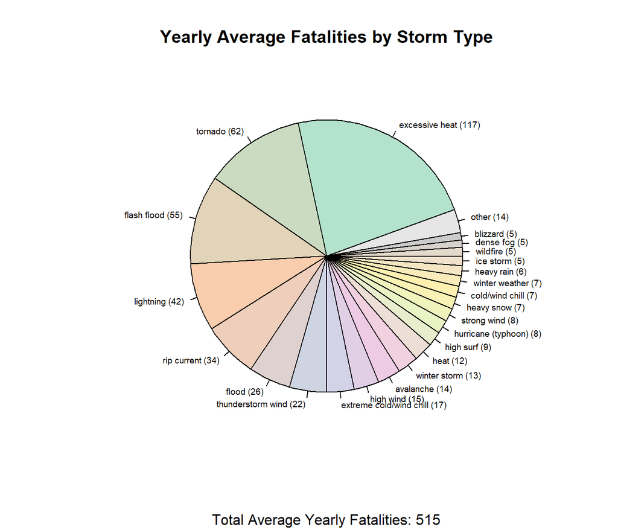

```r
pie(redFatalitiesDat$fatalities,
    labels=sprintf("%s (%.0f)",redFatalitiesDat$type,redFatalitiesDat$fatalities),
    cex=0.6,init.angle=20,col=c(pal(length(redFatalitiesDat$type)-1),otherColor),
    main="Yearly Average Fatalities by Storm Type",
    sub = sprintf("Total Average Yearly Fatalities: %.0f",aveYearlyFatalities))
```

### Injuries

Here we show a plot of the storm types with the highest number of injuries.

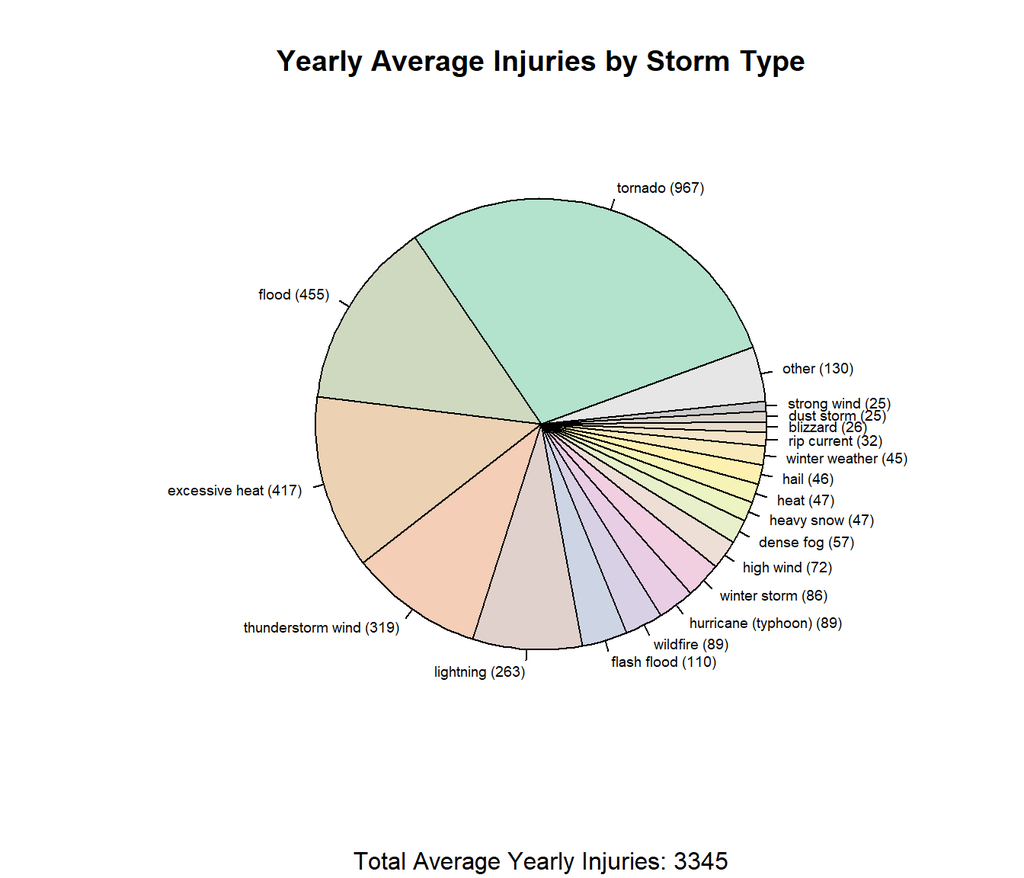

```r
pie(redInjuriesDat$injuries,
    labels=sprintf("%s (%.0f)",redInjuriesDat$type,redInjuriesDat$injuries),
    cex=0.6,init.angle=20,col=c(pal(length(redInjuriesDat$type)-1),otherColor),
    main="Yearly Average Injuries by Storm Type",
    sub = sprintf("Total Average Yearly Injuries: %.0f",aveYearlyInjuries))
```

### Damage Cost in Dollars

Here we show a plot of the storm types with the greatest cost of damge.

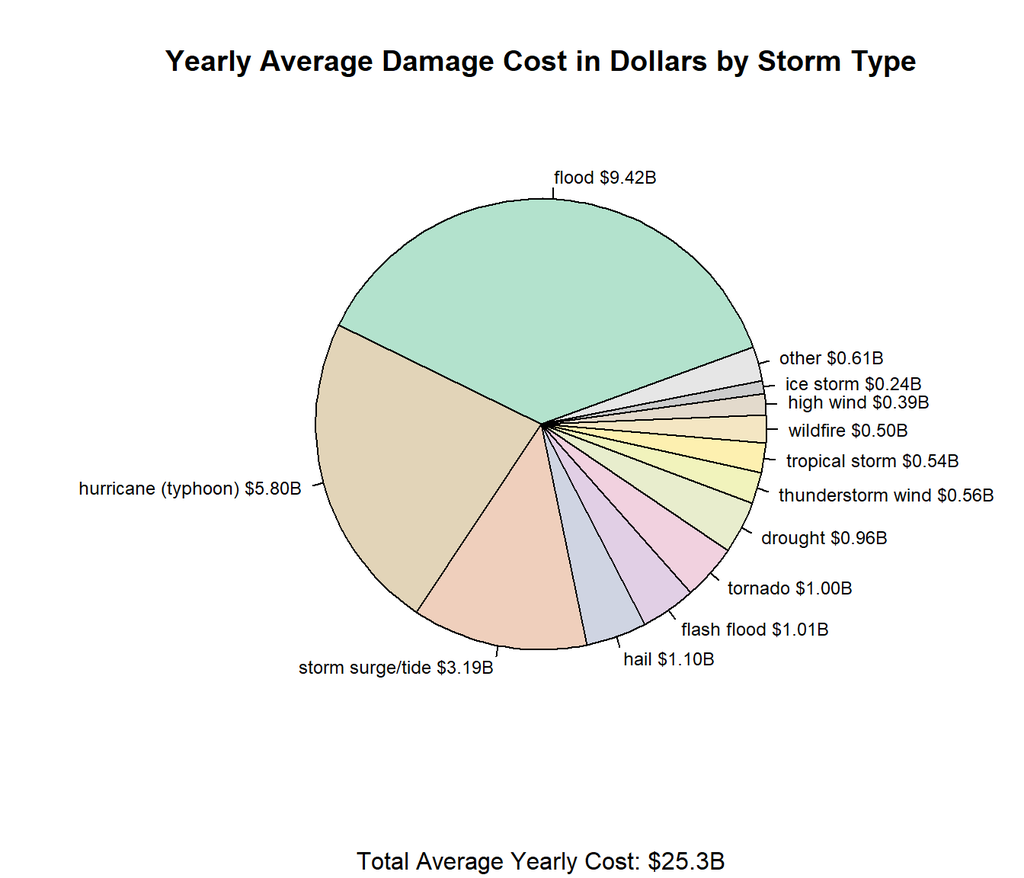

```r
pie(redCostDat$cost,
    labels=sprintf("%s $%.2fB",redCostDat$type,redCostDat$cost/1000000000),
    cex=0.75,init.angle=20,col=c(pal(length(redCostDat$type)-1),otherColor),
    main="Yearly Average Damage Cost in Dollars by Storm Type",
    sub = sprintf("Total Average Yearly Cost: $%.1fB",aveYearlyCost/1000000000))
```

# Supplemental Data

In this section we present some additional commentary and information, including tables of the complete sets of the results.

### General Remarks on Classification and Counting

- The *REMARK* field of the storm data file includes valuable information on the individual events. From this, it is evident the included labels are not always a good description of the actual event. It appears some of the type labels may have been generated from an automated analysis of these remarks. For more accurate labels, it might be worthwhile reexamining the type label using the *REMARK* field.
- In looking at the data, repeat events were found. We did not make an effort to identify these. This is hoever another area that could be examined to get more accurate data.
- As stated in the main writeup, we assigned all storms to a single storm type, although some storms were labeled as multiple types. When assessing damage by type, this is another place an improvement could be made. This should most likely be done in conjunction with the above mentioned analysis of the *REMARK* field.

### Yearly Average Fatalities by Storm Type

Here we present the complete table of yearly average fatalities by storm type.

```r
## complete fatalities table
print(fatalitiesDat,n=length(fatalitiesDat$type))
```

```
## # A tibble: 63 × 3
##    type                       fatalities     count
##    <fct>                           <dbl>     <dbl>
##  1 excessive heat               117.       42.5
##  2 tornado                       61.6     726.
##  3 flash flood                   54.6    1180.
##  4 lightning                     41.6     690.
##  5 rip current                   34.2      37.9
##  6 flood                         25.7     589.
##  7 thunderstorm wind             22.4    6240
##  8 extreme cold/wind chill       17        19.1
##  9 high wind                     15.4     335
## 10 avalanche                     14.3      16.8
## 11 winter storm                  12.7      90
## 12 heat                          11.7       9.6
```

[output cut: 51 more lines]

### Yearly Average Injuries by Storm Type

Here we present the complete table of yearly average injuries by storm type.

```r
## complete injuries table
print(injuriesDat,n=length(injuriesDat$type))
```

```
## # A tibble: 63 × 3
##    type                       injuries     count
##    <fct>                         <dbl>     <dbl>
##  1 tornado                    967.      726.
##  2 flood                      455.      589.
##  3 excessive heat             417.       42.5
##  4 thunderstorm wind          319.     6240
##  5 lightning                  263.      690.
##  6 flash flood                110.     1180.
##  7 wildfire                    89.5      61.7
##  8 hurricane (typhoon)         88.5      13.7
##  9 winter storm                86.1      90
## 10 high wind                   71.5     335
## 11 dense fog                   57        10.1
## 12 heavy snow                  46.8      66.7
```

[output cut: 51 more lines]

### Yearly Average Damage Costs by Storm Type

Here we present the complete table of yearly average damage costs in dollars by storm type.

```r
## complete cost table
print(costDat,n=length(costDat$type))
```

```
## # A tibble: 63 × 3
##    type                              cost     count
##    <fct>                            <dbl>     <dbl>
##  1 flood                      9420160550   589.
##  2 hurricane (typhoon)        5803199787.   13.7
##  3 storm surge/tide           3186325600    14
##  4 hail                       1103891488  1403.
##  5 flash flood                1005645261. 1180.
##  6 tornado                    1003291735.  726.
##  7 drought                     958818600    15.5
##  8 thunderstorm wind           561067045. 6240
##  9 tropical storm              543796223.   21.3
## 10 wildfire                    500305949.   61.7
## 11 high wind                   386382377.  335
## 12 ice storm                   243332754    39.2
```

[output cut: 51 more lines]

### Keyword Matching Analysis

Here we present some of the event label matching results. This can be used when checking the aliases to see if some new aliases should be added or if some should be removed.

We also include some commentary on the aliases we chose to include and not include in this section.

First we calculate a vector of keyword matching counts for each type label from the storm data file.

```r
## this is the count for a given label keyword
labelKeywordCounts <- sapply(labelKeywords,length)
```

##### Labels with no Keyword Matches

```r
## labels with no keyword matches
names(labelKeywords[labelKeywordCounts == 0])
```

```
##  [1] "other"                  "marine accident"        "coastal storm"
##  [4] "beach erosion"          "freezing spray"         "thunderstorm"
##  [7] "coastalstorm"           "high swells"            "coastal erosion"
## [10] "heavy seas"             "high seas"              "rough seas"
## [13] "high water"             "rogue wave"             "drowning"
## [16] "astronomical high tide"
```

##### Labels with One Keyword Match

```r
## labels with 1 keyword match
names(labelKeywords[labelKeywordCounts == 1])
```

```
##   [1] "winter storm"              "tornado"
##   [3] "tstm wind"                 "high wind"
##   [5] "flash flood"               "freezing rain"
##   [7] "extreme cold"              "lightning"
##   [9] "hail"                      "flood"
##  [11] "tstm wind/hail"            "excessive heat"
##  [13] "rip currents"              "heavy snow"
##  [15] "wild/forest fire"          "ice storm"
##  [17] "blizzard"                  "storm surge"
##  [19] "ice jam flood (minor"      "dust storm"
##  [21] "strong wind"               "dust devil"
##  [23] "urban/sml stream fld"      "fog"
##  [25] "rough surf"                "heavy surf"
##  [27] "heavy rain"                "avalanche"
##  [29] "freeze"                    "dry microburst"
```

[output cut: 69 more lines]

##### Labels with Two or More Keyword Matches

As part of our analysis, we explicitly added aliases to map any event labels with multiple matching keywords to control how the event was mapped.

As stated in the document, other approaches could have been taken to map data from events labeled with multiple storm types.

```r
## labels with 2 keyword matches
names(labelKeywords[labelKeywordCounts >= 2])
```

```
## character(0)
```

##### Notable Included Aliases

Here we list some of our aliases that involved a judgement, as opposed to those that were simple alternate terms for a given type.

Here we reference the storm types document, which can be obtained from https://www.nws.noaa.gov/directives/sym/pd01016005curr.pdf.

The following are aliases the involve multiple storm types. In all these examples a judgement was made on the apparent predominant damage type from reading the *REMARK* field of the storm data file. These are however cases where an alternate strategy could be justified, such as count a fraction of the damage on each included type.

*gusty wind/rain* => *strong wind* *gusty wind/hvy rain* => *strong wind* *tstm wind/hail* => *thunderstorm wind* *gusty wind/hail* => *thunderstorm wind* *tstm wind and lightning* => *thunderstorm wind*

##### Notable Omitted labels

- *thunderstorm* - There was one event with this label, which actually corresponded to a snow storm.
- *coastal storm*, *coastalstorm* - Generically this could be many types of storms. In most but not all of the few cases here it corresponded to a winter storm.
- *high water* - This is an unclear term generically. In the examples included it corresponded to flooding of streams
- *freezing spray* - There is no proper category for this
- *rough seas*, *high swells*, *heavy seas*, *high seas*, *rogue wave* - There is no category for this
- *marine accident* - Generically it is unclear of the cause for this.
- *drowning* - Generically it is unclear of the cause for this.
- *astronomical high tide* - There is no proper category for this
- *other* - Generically it is unclear of the cause for this.

### Type Data

Below we print the official storm types and the type aliases used in the analysis.

##### NWS Storm Types

```r
##NWS types, as listed from NWS
print(officialTypes)
```

```
##  [1] "Tsunami"                  "Storm Surge/Tide"
##  [3] "High Surf"                "Seiche"
##  [5] "Rip Current"              "Astronomical Low Tide"
##  [7] "Flash Flood"              "Flood"
##  [9] "Coastal Flood"            "Lakeshore Flood"
## [11] "Heavy Rain"               "Hail"
## [13] "Lightning"                "Hurricane (Typhoon)"
## [15] "Tropical Depression"      "Tropical Storm"
## [17] "Thunderstorm Wind"        "High Wind"
## [19] "Strong Wind"              "Dust Storm"
## [21] "Tornado"                  "Funnel Cloud"
## [23] "Waterspout"               "Dust Devil"
## [25] "Blizzard"                 "Winter Storm"
## [27] "Heavy Snow"               "Ice Storm"
## [29] "Lake-Effect Snow"         "Sleet"
## [31] "Winter Weather"           "Avalanche"
## [33] "Extreme Cold/Wind Chill"  "Frost/Freeze"
## [35] "Cold/Wind Chill"          "Excessive Heat"
## [37] "Heat"                     "Dense Fog"
## [39] "Freezing Fog"             "Debris Flow"
## [41] "Wildfire"                 "Dense Smoke"
## [43] "Drought"                  "Volcanic Ash"
## [45] "Marine Hail"              "Marine High Wind"
## [47] "Marine Strong Wind"       "Marine Thunderstorm Wind"
```

##### Storm Type Aliases

```r
print(typeAliases)
```

```
## $`cold/wind chill`
## [1] "cold"                  "wind chill"            "windchill"
## [4] "hypothermia/exposure"  "hyperthermia/exposure"
##
## $`debris flow`
## [1] "landslide"  "rock slide" "mud slide"  "mudslide"   "landslump"
##
## $`dense fog`
## [1] "fog"
##
## $`dust storm`
## [1] "blowing dust"
##
## $`extreme cold/wind chill`
## [1] "extreme cold"       "extreme wind chill" "extreme windchill"
##
## $`freezing fog`
## [1] "glaze"
##
## $`frost/freeze`
## [1] "frost"     "freeze"    "black ice"
##
## $flood
## [1] "urban/sml stream fld" "dam break"
##
## $`flash flood`
## [1] "flash flood/flood" "flood/flash/flood"
##
## $heat
## [1] "unseasonably warm" "warm weather"
##
## $`heavy rain`
## [1] "torrential rainfall" "hvy rain"            "rain"
## [4] "unseasonal rain"
##
## $`heavy snow`
## [1] "excessive snow"
##
## $`high surf`
## [1] "heavy surf"           "rough surf"           "hazardous surf"
```

[output cut: 20 more lines]

```
##
## $tornado
## [1] "landspout"
##
## $wildfire
## [1] "wild fire"   "grass fire"  "forest fire" "brush fire"
##
## $`winter weather`
##  [1] "freezing rain"       "light snowfall"      "snow and ice"
##  [4] "late season snow"    "light snow"          "snow"
##  [7] "freezing drizzle"    "rain/snow"           "snow squall"
## [10] "mixed precipitation" "blowing snow"        "wintry mix"
## [13] "mixed precip"        "snow squalls"        "falling snow/ice"
## [16] "cold and snow"       "ice roads"           "icy roads"
## [19] "ice on roads"        "ice on road"
```